# report

WCY

2022-11-12

```r
library("readr")
library("dplyr")
library(lubridate)
library(tidyverse)
```

```r
Patterns <- read_csv("C:/Users/wcy/Downloads/safegraph_data_purchase_sep-20-2022/your_data_sep_20_2022_1149am.csv.gz")
Places <- read_csv("C:/Users/wcy/Downloads/safegraph_data_purchase_sep-11-2022/your_data_sep_11_2022_1145pm.csv.gz")
df <- left_join(Patterns, Places, by = "placekey")
df <- left_join(Patterns, Places, by = "placekey")
head(df)
```

```
## # A tibble: 6 × 53
##   placekey        paren…¹ locat…² stree…³ city.x regio…⁴ posta…⁵ safeg…⁶ brand…⁷
##   <chr>           <chr>   <chr>   <chr>   <chr>  <chr>   <chr>   <chr>   <chr>
## 1 222-222@62j-sg… <NA>    Reggie… 1350 T… Boston ma      02120   <NA>    <NA>
## 2 222-222@62j-sh… <NA>    Cuppac… 57 Tra… Boston ma      02118   <NA>    <NA>
## 3 222-223@62j-sh… <NA>    Nmt Me… 27 Wor… Boston ma      02210   <NA>    <NA>
## 4 223-223@62j-sh… <NA>    Fort P… 31 Sta… Boston ma      02109   <NA>    <NA>
## 5 224-223@62j-sh… <NA>    Come S… 1 Mari… Boston ma      02210   <NA>    <NA>
## 6 226-223@62j-sh… <NA>    The Pa… 19 Nor… Boston ma      02113   <NA>    <NA>
## # … with 44 more variables: date_range_start <dttm>, date_range_end <dttm>,
## #   raw_visit_counts <dbl>, raw_visitor_counts <dbl>, visits_by_day <chr>,
## #   poi_cbg <dbl>, visitor_home_cbgs <chr>, visitor_home_aggregation <chr>,
## #   visitor_daytime_cbgs <chr>, visitor_country_of_origin <chr>,
## #   distance_from_home <dbl>, median_dwell <dbl>, bucketed_dwell_times <chr>,
## #   related_same_day_brand <chr>, related_same_month_brand <chr>,
## #   popularity_by_hour <chr>, popularity_by_day <chr>, device_type <chr>, …
```

```r
df$date_range_start <- as.Date(df$date_range_start,"%d-%m-%Y")
head(df)
```

```
## # A tibble: 6 × 53
##   placekey        paren…¹ locat…² stree…³ city.x regio…⁴ posta…⁵ safeg…⁶ brand…⁷
##   <chr>           <chr>   <chr>   <chr>   <chr>  <chr>   <chr>   <chr>   <chr>
## 1 222-222@62j-sg… <NA>    Reggie… 1350 T… Boston ma      02120   <NA>    <NA>
## 2 222-222@62j-sh… <NA>    Cuppac… 57 Tra… Boston ma      02118   <NA>    <NA>
## 3 222-223@62j-sh… <NA>    Nmt Me… 27 Wor… Boston ma      02210   <NA>    <NA>
## 4 223-223@62j-sh… <NA>    Fort P… 31 Sta… Boston ma      02109   <NA>    <NA>
## 5 224-223@62j-sh… <NA>    Come S… 1 Mari… Boston ma      02210   <NA>    <NA>
## 6 226-223@62j-sh… <NA>    The Pa… 19 Nor… Boston ma      02113   <NA>    <NA>
## # … with 44 more variables: date_range_start <date>, date_range_end <dttm>,
## #   raw_visit_counts <dbl>, raw_visitor_counts <dbl>, visits_by_day <chr>,
## #   poi_cbg <dbl>, visitor_home_cbgs <chr>, visitor_home_aggregation <chr>,
## #   visitor_daytime_cbgs <chr>, visitor_country_of_origin <chr>,
## #   distance_from_home <dbl>, median_dwell <dbl>, bucketed_dwell_times <chr>,
## #   related_same_day_brand <chr>, related_same_month_brand <chr>,
## #   popularity_by_hour <chr>, popularity_by_day <chr>, device_type <chr>, …
```

```r
Sys.setlocale("LC_TIME", "English")
```

```
## [1] "English_United States.1252"
```

```r
options(scipen = 20)
```

```r
# the number of na in naics column in places dataset
nacount <- Places[is.na(Places$naics_code),]
nacount
```

```
## # A tibble: 10 × 22
##    placekey       paren…¹ locat…² safeg…³ brands top_c…⁴ sub_c…⁵ naics…⁶ latit…⁷
##    <chr>          <chr>   <chr>   <chr>   <chr>  <chr>   <chr>     <dbl>   <dbl>
##  1 24d-222@62j-s… 222-22… Copley… <NA>    <NA>   <NA>    <NA>         NA    42.4
##  2 22c-222@62j-s… <NA>    Artu O… <NA>    <NA>   <NA>    <NA>         NA    42.4
##  3 226-223@62j-s… zzw-22… Jordan… <NA>    <NA>   <NA>    <NA>         NA    42.3
##  4 zzw-224@62j-s… zzw-22… Berkle… <NA>    <NA>   <NA>    <NA>         NA    42.3
##  5 23p-224@62j-s… <NA>    Dumpli… <NA>    <NA>   <NA>    <NA>         NA    42.4
##  6 223-223@62j-s… <NA>    Huntin… <NA>    <NA>   <NA>    <NA>         NA    42.3
##  7 27d-222@62j-s… 27d-22… Shuber… <NA>    <NA>   <NA>    <NA>         NA    42.4
##  8 22t-222@62j-s… 22t-22… Citize… <NA>    <NA>   <NA>    <NA>         NA    42.4
##  9 zzw-223@62j-s… 248-22… Cutler… <NA>    <NA>   <NA>    <NA>         NA    42.4
## 10 243-222@62j-s… 27d-22… Wang T… <NA>    <NA>   <NA>    <NA>         NA    42.4
## # … with 13 more variables: longitude <dbl>, street_address <chr>, city <chr>,
## #   region <chr>, postal_code <chr>, iso_country_code <chr>,
## #   phone_number <dbl>, open_hours <chr>, category_tags <chr>,
## #   opened_on <date>, closed_on <date>, tracking_closed_since <date>,
## #   geometry_type <chr>, and abbreviated variable names ¹parent_placekey,
## #   ²location_name, ³safegraph_brand_ids, ⁴top_category, ⁵sub_category,
## #   ⁶naics_code, ⁷latitude
```

```r
# the number of na in naics column in df
nacount2 <- df[is.na(df$naics_code),]
nacount2
```

```
## # A tibble: 688 × 53
##    placekey       paren…¹ locat…² stree…³ city.x regio…⁴ posta…⁵ safeg…⁶ brand…⁷
##    <chr>          <chr>   <chr>   <chr>   <chr>  <chr>   <chr>   <chr>   <chr>
##  1 22g-222@62j-s… <NA>    Geoffr… C8 Shi… Boston ma      02129   <NA>    <NA>
##  2 222-222@62j-s… <NA>    Tropic… 450 Me… Boston ma      02119   <NA>    <NA>
##  3 27w-222@62j-s… <NA>    Fideli… 125 Hi… Boston ma      02110   <NA>    <NA>
##  4 zzw-222@62j-s… zzw-22… Boston… 139 Tr… Boston ma      02116   <NA>    <NA>
##  5 222-222@62j-s… <NA>    Portma… 30 Ips… Boston ma      02215   <NA>    <NA>
##  6 229-227@62j-s… <NA>    Ned De… 1 Fane… Boston ma      02109   <NA>    <NA>
##  7 22p-224@62j-s… zzw-22… Greene… 1 Inte… Boston ma      02110   <NA>    <NA>
##  8 24c-222@62j-s… <NA>    Olives… 81 Pem… Boston ma      02118   <NA>    <NA>
##  9 zzw-22g@62j-s… <NA>    Stough… 645 Wa… Boston ma      02111   <NA>    <NA>
## 10 zzw-222@62j-s… <NA>    Harvar… 10 Sha… Boston ma      02115   SG_BRA… Barnes…
## # … with 678 more rows, 44 more variables: date_range_start <date>,
## #   date_range_end <dttm>, raw_visit_counts <dbl>, raw_visitor_counts <dbl>,
## #   visits_by_day <chr>, poi_cbg <dbl>, visitor_home_cbgs <chr>,
## #   visitor_home_aggregation <chr>, visitor_daytime_cbgs <chr>,
## #   visitor_country_of_origin <chr>, distance_from_home <dbl>,
## #   median_dwell <dbl>, bucketed_dwell_times <chr>,
## #   related_same_day_brand <chr>, related_same_month_brand <chr>, …
```

```r
df_filter<- subset(df, naics_code==722513)
head(df_filter)
```

```
## # A tibble: 6 × 53
##   placekey        paren…¹ locat…² stree…³ city.x regio…⁴ posta…⁵ safeg…⁶ brand…⁷
##   <chr>           <chr>   <chr>   <chr>   <chr>  <chr>   <chr>   <chr>   <chr>
## 1 22k-222@62j-sj… <NA>    Cafe24  24 Fen… Boston ma      02215   <NA>    <NA>
## 2 26k-222@62j-sj… <NA>    Billy'… 57 Ber… Boston ma      02116   <NA>    <NA>
## 3 zzw-224@62j-sj… zzw-22… Chipot… 8 Park… Boston ma      02116   SG_BRA… Chipot…
## 4 zzy-222@62j-qn… zzz-22… Sulliv… 2080 D… Boston ma      02127   <NA>    <NA>
## 5 22d-222@62j-sh… <NA>    Black … 131 Tr… Boston ma      02111   <NA>    <NA>
## 6 24f-222@62j-sg… <NA>    Bonchon 123 Br… Boston ma      02134   SG_BRA… Bonchon
## # … with 44 more variables: date_range_start <date>, date_range_end <dttm>,
## #   raw_visit_counts <dbl>, raw_visitor_counts <dbl>, visits_by_day <chr>,
## #   poi_cbg <dbl>, visitor_home_cbgs <chr>, visitor_home_aggregation <chr>,
## #   visitor_daytime_cbgs <chr>, visitor_country_of_origin <chr>,
## #   distance_from_home <dbl>, median_dwell <dbl>, bucketed_dwell_times <chr>,
## #   related_same_day_brand <chr>, related_same_month_brand <chr>,
## #   popularity_by_hour <chr>, popularity_by_day <chr>, device_type <chr>, …
```

```r
count<-df_filter %>% group_by(location_name.x,street_address.x) %>%count()%>%arrange(n)
count
```

```
## # A tibble: 340 × 3
## # Groups:   location_name.x, street_address.x [340]
##    location_name.x       street_address.x         n
##    <chr>                 <chr>                <int>
##  1 Blue Bottle Coffee    113 Autumn Ln            1
##  2 BU GSU Back Court     775 Commonwealth Ave     1
##  3 CAVA                  800 Boylston St          1
##  4 MrBeast Burger        58 Seaport Blvd          1
##  5 Poke Works            4 S Market St            1
##  6 Taco Bell             449 W Broadway           1
##  7 BiBim Box             196 Quincy St            2
##  8 Boston Speed Dog      42 Newmarket Sq          2
##  9 Broad Street Paulie's 64 Broad St              2
## 10 Bull Market Deli      7 Liberty Sq             2
## # … with 330 more rows
```

```r
lessthan10 <-count %>% filter(n<10)
lessthan10
```

```
## # A tibble: 340 × 3
## # Groups:   location_name.x, street_address.x [340]
##    location_name.x       street_address.x         n
##    <chr>                 <chr>                <int>
##  1 Blue Bottle Coffee    113 Autumn Ln            1
##  2 BU GSU Back Court     775 Commonwealth Ave     1
##  3 CAVA                  800 Boylston St          1
##  4 MrBeast Burger        58 Seaport Blvd          1
##  5 Poke Works            4 S Market St            1
##  6 Taco Bell             449 W Broadway           1
##  7 BiBim Box             196 Quincy St            2
##  8 Boston Speed Dog      42 Newmarket Sq          2
##  9 Broad Street Paulie's 64 Broad St              2
## 10 Bull Market Deli      7 Liberty Sq             2
## # … with 330 more rows
```

```r
tentotwenty <-count %>% filter(n>=10 & n<20)
tentotwenty
```

```
## # A tibble: 0 × 3
## # Groups:   location_name.x, street_address.x [0]
## # … with 3 variables: location_name.x <chr>, street_address.x <chr>, n <int>
```

```r
twentytothirty <-count %>% filter(n>=20 & n<30)
twentytothirty
```

```
## # A tibble: 0 × 3
## # Groups:   location_name.x, street_address.x [0]
## # … with 3 variables: location_name.x <chr>, street_address.x <chr>, n <int>
```

```r
thirtytoforty <-count %>% filter(n>=30 & n<40)
thirtytoforty
```

```
## # A tibble: 0 × 3
## # Groups:   location_name.x, street_address.x [0]
## # … with 3 variables: location_name.x <chr>, street_address.x <chr>, n <int>
```

```r
fortytofifty <-count %>% filter(n>=40 & n<50)
fortytofifty
```

```
## # A tibble: 0 × 3
## # Groups:   location_name.x, street_address.x [0]
## # … with 3 variables: location_name.x <chr>, street_address.x <chr>, n <int>
```

```r
fiftytosixty <-count %>% filter(n>=50 & n<60)
fiftytosixty
```

```
## # A tibble: 0 × 3
## # Groups:   location_name.x, street_address.x [0]
## # … with 3 variables: location_name.x <chr>, street_address.x <chr>, n <int>
```

```r
sixtytoseventy <-count %>% filter(n>=60 & n<=70)
sixtytoseventy
```

```
## # A tibble: 0 × 3
## # Groups:   location_name.x, street_address.x [0]
## # … with 3 variables: location_name.x <chr>, street_address.x <chr>, n <int>
```

#### disadvantages: one of the most disadvantages of this method is that : Because the primary key of the pattern and places dataset can not be fully corresponded to, in the time of left join lost a lot of data: we can see that the number of na in places is 10, but the number of na in df became 688, which indicates that the placekey does not fully correspond.

#### advantages: The most significant advantage of this method is that the naics code is classified in a very strict and standardized way, and there are naics that correspond directly to fast food restaurants, so the results can be obtained more accurately.

### And we want to see the summary of these row visit number to identify whether the results of this method makes sense.

```r
# sum the number of visits to different branches of the same brand
df_filter_sum <- df_filter %>% group_by(location_name.x) %>% summarise(sum=sum(raw_visit_counts)) %>% arrange(sum)
df_filter_sum
```

```
## # A tibble: 248 × 2
##    location_name.x       sum
##    <chr>               <dbl>
##  1 Bull Market Deli        2
##  2 Rainbow Roller Cafe    12
##  3 BiBim Box              14
##  4 Boston Speed Dog       15
##  5 Hollywood Deli         15
##  6 Rosario Grocery        16
##  7 Mulligans              18
##  8 Brown Bag Cafe         19
##  9 Malgeri's              22
## 10 Jazzman's Cafe         31
## # … with 238 more rows
```

```r
# see the statistical feature of the raw visit number
summary(df_filter_sum)
```

```
##  location_name.x         sum
##  Length:248         Min.   :     2.0
##  Class :character   1st Qu.:   252.0
##  Mode  :character   Median :   590.5
##                     Mean   :  4068.1
##                     3rd Qu.:  1495.0
##                     Max.   :298609.0
```

```r
# 3rd Qu.is 1495.0 , so we identify the restaurants whose raw visit number greater than 1500 as first group.
firstgroup <- subset(df_filter_sum, sum>1500)
firstgroup
```

```
## # A tibble: 62 × 2
##    location_name.x          sum
##    <chr>                  <dbl>
##  1 Boston Doghouse         1501
##  2 Gong Cha                1505
##  3 Poke Works              1553
##  4 Bluestone Lane          1566
##  5 Pueblo Viejo Cafe       1591
##  6 Love Art Sushi          1595
##  7 The Sausage Guy         1660
##  8 Susan's Deli of Course  1675
##  9 Fargo's Deli Of Course  1739
## 10 Caffebene               1762
## # … with 52 more rows
```

```r
# 1st Qu. is 252.0, so we identify the restaurants whose raw visit number greater than 252 and less than 3000 as second group.
secondgroup <- subset(df_filter_sum, sum>252 & sum <=3000)
secondgroup
```

```
## # A tibble: 151 × 2
##    location_name.x              sum
##    <chr>                      <dbl>
##  1 Viga Eatery & Catering       259
##  2 Clover FIN                   263
##  3 Counterpoint Cafe            271
##  4 Irashai Sushi And Teriyaki   275
##  5 Jazz Cafe                    275
##  6 Sauce                        276
##  7 Panini Sante                 277
##  8 Shrafft's Center Cafe        277
##  9 Caffe di Marina              282
## 10 Cocobeet                     282
## # … with 141 more rows
```

```r
# we identify the restaurants whose raw visit number less than 252 as third group.
thirdgroup <- subset(df_filter_sum, sum<252)
thirdgroup
```

```
## # A tibble: 61 × 2
##    location_name.x       sum
##    <chr>               <dbl>
##  1 Bull Market Deli        2
##  2 Rainbow Roller Cafe    12
##  3 BiBim Box              14
##  4 Boston Speed Dog       15
##  5 Hollywood Deli         15
##  6 Rosario Grocery        16
##  7 Mulligans              18
##  8 Brown Bag Cafe         19
##  9 Malgeri's              22
## 10 Jazzman's Cafe         31
## # … with 51 more rows
```

```r
# detail about Clover Food Lab and Black Seed Cafe & Grill
Clover <- subset(df_filter, location_name.x == "Clover Food Lab")
Clover
```

```
## # A tibble: 61 × 53
##    placekey       paren…¹ locat…² stree…³ city.x regio…⁴ posta…⁵ safeg…⁶ brand…⁷
##    <chr>          <chr>   <chr>   <chr>   <chr>  <chr>   <chr>   <chr>   <chr>
##  1 zzy-223@62j-s… zzw-22… Clover… Park S… Boston ma      02210   SG_BRA… Clover…
##  2 zzy-223@62j-s… zzw-22… Clover… Park S… Boston ma      02210   SG_BRA… Clover…
##  3 zzy-224@62j-s… <NA>    Clover… Newbur… Boston ma      02105   SG_BRA… Clover…
##  4 223-224@62j-s… <NA>    Clover… 565 Bo… Boston ma      02116   SG_BRA… Clover…
##  5 25m-222@62j-s… zzw-22… Clover… 800 Bo… Boston ma      02199   SG_BRA… Clover…
##  6 22f-225@62j-s… <NA>    Clover… 27 Sch… Boston ma      02108   SG_BRA… Clover…
##  7 zzy-223@62j-s… zzw-22… Clover… Park S… Boston ma      02210   SG_BRA… Clover…
##  8 222-226@62j-s… <NA>    Clover… 160 Fe… Boston ma      02110   SG_BRA… Clover…
##  9 25m-222@62j-s… zzw-22… Clover… 800 Bo… Boston ma      02199   SG_BRA… Clover…
## 10 22f-225@62j-s… <NA>    Clover… 27 Sch… Boston ma      02108   SG_BRA… Clover…
## # … with 51 more rows, 44 more variables: date_range_start <date>,
## #   date_range_end <dttm>, raw_visit_counts <dbl>, raw_visitor_counts <dbl>,
## #   visits_by_day <chr>, poi_cbg <dbl>, visitor_home_cbgs <chr>,
## #   visitor_home_aggregation <chr>, visitor_daytime_cbgs <chr>,
## #   visitor_country_of_origin <chr>, distance_from_home <dbl>,
## #   median_dwell <dbl>, bucketed_dwell_times <chr>,
## #   related_same_day_brand <chr>, related_same_month_brand <chr>, …
```

```r
Black <- subset(df_filter, location_name.x == "Black Seed Cafe & Grill")
Black
```

```
## # A tibble: 8 × 53
##   placekey        paren…¹ locat…² stree…³ city.x regio…⁴ posta…⁵ safeg…⁶ brand…⁷
##   <chr>           <chr>   <chr>   <chr>   <chr>  <chr>   <chr>   <chr>   <chr>
## 1 22d-222@62j-sh… <NA>    Black … 131 Tr… Boston ma      02111   <NA>    <NA>
## 2 22d-222@62j-sh… <NA>    Black … 131 Tr… Boston ma      02111   <NA>    <NA>
## 3 22d-222@62j-sh… <NA>    Black … 131 Tr… Boston ma      02111   <NA>    <NA>
## 4 22d-222@62j-sh… <NA>    Black … 131 Tr… Boston ma      02111   <NA>    <NA>
## 5 22d-222@62j-sh… <NA>    Black … 131 Tr… Boston ma      02111   <NA>    <NA>
## 6 22d-222@62j-sh… <NA>    Black … 131 Tr… Boston ma      02111   <NA>    <NA>
## 7 22d-222@62j-sh… <NA>    Black … 131 Tr… Boston ma      02111   <NA>    <NA>
## 8 22d-222@62j-sh… <NA>    Black … 131 Tr… Boston ma      02111   <NA>    <NA>
## # … with 44 more variables: date_range_start <date>, date_range_end <dttm>,
## #   raw_visit_counts <dbl>, raw_visitor_counts <dbl>, visits_by_day <chr>,
## #   poi_cbg <dbl>, visitor_home_cbgs <chr>, visitor_home_aggregation <chr>,
## #   visitor_daytime_cbgs <chr>, visitor_country_of_origin <chr>,
## #   distance_from_home <dbl>, median_dwell <dbl>, bucketed_dwell_times <chr>,
## #   related_same_day_brand <chr>, related_same_month_brand <chr>,
## #   popularity_by_hour <chr>, popularity_by_day <chr>, device_type <chr>, …
```

#### We find some intersting facts after we divide the three groups. In group 1, There seems to be two outliers here: Clover Food Lab（the sum is 279345）;Black Seed Cafe & Grill(the sum is 298609 ).They were a bit too big compared to the rest of the first group, so we looked at the details through the filter function, but found no anomalies. We are considering whether we should remove these two data, can you give us some advice?

#Continue on Method1: Verification

```r
tail(secondgroup,n=10)
```

```
## # A tibble: 10 × 2
##    location_name.x             sum
##    <chr>                     <dbl>
##  1 Burro Bar South End        2118
##  2 Wingstop                   2119
##  3 The Capital Burger         2288
##  4 Dig Inn                    2352
##  5 Five Guys                  2359
##  6 Burger King                2410
##  7 La Colombe                 2473
##  8 Anna's Taqueria            2524
##  9 Fins Sushi and Grill       2540
## 10 Popeyes Louisiana Kitchen  2770
```

```r
tail(thirdgroup,n=10)
```

```
## # A tibble: 10 × 2
##    location_name.x                 sum
##    <chr>                         <dbl>
##  1 Samira's Homemade               190
##  2 Poke City                       200
##  3 Deli Belli                      208
##  4 Poke Station and Kitchen        211
##  5 D'Angelo Grilled Sandwiches     212
##  6 Sushi Kappo                     213
##  7 Scali Cafe                      219
##  8 Jennifer Lee's Gourmet Bakery   223
##  9 Soup Shack                      237
## 10 Noon Mediterranean              244
```

```r
tail(firstgroup,n=10)
```

```
## # A tibble: 10 × 2
##    location_name.x            sum
##    <chr>                    <dbl>
##  1 Subway                   11143
##  2 Breadwinners             13625
##  3 Einstein Brothers        16370
##  4 McDonald's               16795
##  5 Tasty Burger             16956
##  6 B.GOOD                   17607
##  7 Tatte Bakery & Cafe      18027
##  8 MOOYAH                   60144
##  9 Clover Food Lab         279345
## 10 Black Seed Cafe & Grill 298609
```

##The distance to the store is also a key factor in people’s choice to visit. ‘distance_from_home’ is the distance that visitors travel from their home to the site of visit. This record for each store is the median of the distance traveled by all visitors. We think this data can help us to study the sources of visitors to different stores, for some independent stores, the analysis of this data may help them make the decision to open a branch to attract more customers from the surrounding area. (Reduce the distance visitors move and get more visitors).

```r
#Group 3 which has biggest visit number
Tatte <- subset(df_filter, location_name.x == "Tatte Bakery & Cafe")
Tatte
```

```
## # A tibble: 31 × 53
##    placekey       paren…¹ locat…² stree…³ city.x regio…⁴ posta…⁵ safeg…⁶ brand…⁷
##    <chr>          <chr>   <chr>   <chr>   <chr>  <chr>   <chr>   <chr>   <chr>
##  1 zzw-225@62j-s… <NA>    Tatte … 399 Bo… Boston ma      02116   <NA>    <NA>
##  2 22r-223@62j-s… <NA>    Tatte … 369 Hu… Boston ma      02115   <NA>    <NA>
##  3 22r-223@62j-s… <NA>    Tatte … 369 Hu… Boston ma      02115   <NA>    <NA>
##  4 zzw-223@62j-s… zzw-22… Tatte … 80 Boy… Boston ma      02116   <NA>    <NA>
##  5 22r-223@62j-s… <NA>    Tatte … 369 Hu… Boston ma      02115   <NA>    <NA>
##  6 22r-223@62j-s… <NA>    Tatte … 369 Hu… Boston ma      02115   <NA>    <NA>
##  7 222-224@62j-s… <NA>    Tatte … 345 Ha… Boston ma      02118   <NA>    <NA>
##  8 zzw-223@62j-s… zzw-22… Tatte … 80 Boy… Boston ma      02116   <NA>    <NA>
##  9 222-224@62j-s… <NA>    Tatte … 345 Ha… Boston ma      02118   <NA>    <NA>
## 10 22r-223@62j-s… <NA>    Tatte … 369 Hu… Boston ma      02115   <NA>    <NA>
## # … with 21 more rows, 44 more variables: date_range_start <date>,
## #   date_range_end <dttm>, raw_visit_counts <dbl>, raw_visitor_counts <dbl>,
## #   visits_by_day <chr>, poi_cbg <dbl>, visitor_home_cbgs <chr>,
## #   visitor_home_aggregation <chr>, visitor_daytime_cbgs <chr>,
## #   visitor_country_of_origin <chr>, distance_from_home <dbl>,
## #   median_dwell <dbl>, bucketed_dwell_times <chr>,
## #   related_same_day_brand <chr>, related_same_month_brand <chr>, …
```

```r
Tatte_d <- Tatte %>% select(distance_from_home) %>% filter(is.na(distance_from_home) != 1)
Tatte_d_mean <- sapply(Tatte_d,mean)
Tatte_d_mean #52737.9
```

```
## distance_from_home
##            52737.9
```

```r
MOOYAH <- subset(df_filter, location_name.x == "MOOYAH")
#Delete all NA value in distance from home and only select distance
MOOYAH_d <- MOOYAH %>% select(distance_from_home) %>% filter(is.na(distance_from_home) != 1)
MOOYAH_d
```

```
## # A tibble: 6 × 1
##   distance_from_home
##                <dbl>
## 1             150495
## 2             218523
## 3              65509
## 4             117864
## 5             106584
## 6             202411
```

```r
MOOYAH_d_mean <- sapply(MOOYAH_d,mean)
MOOYAH_d_mean#143564.3
```

```
## distance_from_home
##           143564.3
```

```r
B.GOOD <- subset(df_filter, location_name.x == "B.GOOD")
#Delete all NA value in distance from home and only select distance
B.GOOD_d <- B.GOOD %>% select(distance_from_home) %>% filter(is.na(distance_from_home) != 1)
B.GOOD_d <- sapply(B.GOOD_d,mean)
B.GOOD_d #35398.43
```

```
## distance_from_home
##           35398.43
```

```r
Tasty <- subset(df_filter, location_name.x == "Tasty Burger")
#Delete all NA value in distance from home and only select distance
Tasty_d <- Tasty %>% select(distance_from_home) %>% filter(is.na(distance_from_home) != 1)
Tasty_d <- sapply(Tasty_d,mean)
Tasty_d #32586.38
```

```
## distance_from_home
##           32586.38
```

```r
McDonald <- subset(df_filter, location_name.x == "McDonald's")
#Delete all NA value in distance from home and only select distance
McDonald_d <- McDonald %>% select(distance_from_home) %>% filter(is.na(distance_from_home) != 1)
McDonald_d <- sapply(McDonald_d,mean)
McDonald_d # 20230.44
```

```
## distance_from_home
##           20230.44
```

```r
(McDonald_d + Tasty_d + B.GOOD_d+ MOOYAH_d_mean + Tatte_d_mean)/5
```

```
## distance_from_home
##            56903.5
```

```r
# 56903.5 for this group.



#Group 2
Popeyes <- subset(df_filter, location_name.x == "Popeyes Louisiana Kitchen")
#Delete all NA value in distance from home and only select distance
Popeyes_d <- Popeyes %>% select(distance_from_home) %>% filter(is.na(distance_from_home) != 1)
Popeyes_d <- sapply(Popeyes_d,mean)
Popeyes_d #37737
```

```
## distance_from_home
##              37737
```

```r
Fins <- subset(df_filter, location_name.x == "Fins Sushi and Grill")
#Delete all NA value in distance from home and only select distance
Fins_d <- Fins %>% select(distance_from_home) %>% filter(is.na(distance_from_home) != 1)
Fins_d <- sapply(Fins_d,mean)
Fins_d #92258.75
```

```
## distance_from_home
##           92258.75
```

```r
Anna <- subset(df_filter, location_name.x == "Anna's Taqueria")
#Delete all NA value in distance from home and only select distance
Anna_d <- Anna %>% select(distance_from_home) %>% filter(is.na(distance_from_home) != 1)
Anna_d <- sapply(Anna_d,mean)
Anna_d #41782.19
```

```
## distance_from_home
##           41782.19
```

```r
La <- subset(df_filter, location_name.x == "La Colombe")
#Delete all NA value in distance from home and only select distance
La_d <- La %>% select(distance_from_home) %>% filter(is.na(distance_from_home) != 1)
La_d <- sapply(La_d,mean)
La_d #24469.62
```

```
## distance_from_home
##           24469.62
```

```r
Burger <- subset(df_filter, location_name.x == "Burger King")
#Delete all NA value in distance from home and only select distance
Burger_d <- Burger %>% select(distance_from_home) %>% filter(is.na(distance_from_home) != 1)
Burger_d <- sapply(Burger_d,mean)
Burger_d #9738.25
```

```
## distance_from_home
##            9738.25
```

```r
(Burger_d + La_d + Anna_d + Fins_d + Popeyes_d) / 5
```

```
## distance_from_home
##           41197.16
```

```r
# Group 2:   41197.16




#Group 1 (Visit number is the smallest)
Noon <- subset(df_filter, location_name.x == "Noon Mediterranean")
#Delete all NA value in distance from home and only select distance
Noon_d <- Noon %>% select(distance_from_home) %>% filter(is.na(distance_from_home) != 1)
Noon_d
```

```
## # A tibble: 4 × 1
##   distance_from_home
##                <dbl>
## 1              31987
## 2              35047
## 3              24175
## 4              24246
```

```r
Noon_d_mean <- sapply(Noon_d,mean)
Noon_d_mean#28863.75
```

```
## distance_from_home
##           28863.75
```

```r
Soup <- subset(df_filter, location_name.x == "Soup Shack")
#Delete all NA value in distance from home and only select distance
Soup_d <- Soup %>% select(distance_from_home) %>% filter(is.na(distance_from_home) != 1)
Soup_d
```

```
## # A tibble: 8 × 1
##   distance_from_home
##                <dbl>
## 1               5592
## 2               3936
## 3               4707
## 4               4445
## 5               4607
## 6               7034
## 7               3526
## 8               4076
```

```r
Soup_d_mean <- sapply(Soup_d,mean)
Soup_d_mean#4740.375
```

```
## distance_from_home
##           4740.375
```

```r
Jennifer <- subset(df_filter, location_name.x == "Jennifer Lee's Gourmet Bakery")
#Delete all NA value in distance from home and only select distance
Jennifer_d <- Jennifer %>% select(distance_from_home) %>% filter(is.na(distance_from_home) != 1)
Jennifer_d
```

```
## # A tibble: 3 × 1
##   distance_from_home
##                <dbl>
## 1              27276
## 2               9971
## 3              27495
```

```r
Jennifer_d_mean <- sapply(Jennifer_d,mean)
Jennifer_d_mean#21580.67
```

```
## distance_from_home
##           21580.67
```

```r
Scali <- subset(df_filter, location_name.x == "Scali Cafe")
#Delete all NA value in distance from home and only select distance
Scali_d <- Scali %>% select(distance_from_home) %>% filter(is.na(distance_from_home) != 1)
Scali_d <- sapply(Scali_d,mean)
Scali_d #49526.5
```

```
## distance_from_home
##            49526.5
```

```r
Sushi <- subset(df_filter, location_name.x == "Sushi Kappo")
#Delete all NA value in distance from home and only select distance
Sushi_d <- Sushi %>% select(distance_from_home) %>% filter(is.na(distance_from_home) != 1)
Sushi_d <- sapply(Sushi_d,mean)
Sushi_d #26724.75
```

```
## distance_from_home
##           26724.75
```

```r
(Sushi_d+ Scali_d+ Jennifer_d_mean + Soup_d_mean+ Noon_d_mean) / 5
```

```
## distance_from_home
##           26287.21
```

```r
#  26287.21 for the first group
```

#Select the specific branch that needs to be studied, precise to the specific address of a single branch, as in the previous section

##We are not going to use data from Tatte’s Distance from home because its numerical value looks suspicious.

#MOOYAH <- subset(df_filter, location_name.x == “MOOYAH”)

```r
Tatte <- subset(df_filter, location_name.x == "Tatte Bakery & Cafe")
Tatte <- Tatte %>% filter(is.na(distance_from_home) != 1) %>% select(distance_from_home,raw_visit_counts,date_range_start,location_name.x,street_address.x) %>% arrange(date_range_start) %>% filter(street_address.x == "369 Huntington Ave")
## select address: 369 Huntington Ave
Tatte
```

```
## # A tibble: 8 × 5
##   distance_from_home raw_visit_counts date_range_start location_name.x   stree…¹
##                <dbl>            <dbl> <date>           <chr>             <chr>
## 1             153357             1785 2022-01-01       Tatte Bakery & C… 369 Hu…
## 2                562             2451 2022-02-01       Tatte Bakery & C… 369 Hu…
## 3                579             2470 2022-03-01       Tatte Bakery & C… 369 Hu…
## 4                671             2495 2022-04-01       Tatte Bakery & C… 369 Hu…
## 5                924             1068 2022-05-01       Tatte Bakery & C… 369 Hu…
## 6               1039              730 2022-06-01       Tatte Bakery & C… 369 Hu…
## 7              11211              598 2022-07-01       Tatte Bakery & C… 369 Hu…
## 8              23062              571 2022-08-01       Tatte Bakery & C… 369 Hu…
## # … with abbreviated variable name ¹street_address.x
```

```r
##In January and July, the numbers in August are very large, meaning that guests seem to come from far away, and the numbers in February to June are small, meaning that there are no guests from far away. I think this is not an outlier, because considering that this period is the holiday of the students, they are visiting from a long distance.


B.GOOD <- B.GOOD %>% filter(is.na(distance_from_home) != 1) %>% select(distance_from_home,date_range_end,date_range_start,location_name.x,street_address.x) %>% arrange(date_range_start) %>% filter(street_address.x == "359 Huntington Ave")
B.GOOD
```

```
## # A tibble: 8 × 5
##   distance_from_home date_range_end      date_range_start location_nam…¹ stree…²
##                <dbl> <dttm>              <date>           <chr>          <chr>
## 1             238981 2022-02-01 05:00:00 2022-01-01       B.GOOD         359 Hu…
## 2                528 2022-03-01 05:00:00 2022-02-01       B.GOOD         359 Hu…
## 3                534 2022-04-01 04:00:00 2022-03-01       B.GOOD         359 Hu…
## 4                543 2022-05-01 04:00:00 2022-04-01       B.GOOD         359 Hu…
## 5                535 2022-06-01 04:00:00 2022-05-01       B.GOOD         359 Hu…
## 6                709 2022-07-01 04:00:00 2022-06-01       B.GOOD         359 Hu…
## 7             149401 2022-08-01 04:00:00 2022-07-01       B.GOOD         359 Hu…
## 8              83300 2022-09-01 04:00:00 2022-08-01       B.GOOD         359 Hu…
## # … with abbreviated variable names ¹location_name.x, ²street_address.x
```

```r
# select address: 359 Huntington Ave
#The store has the same trend: January and July, August numbers are very large, meaning customers seem to come from far away, and February to June numbers are small, meaning there are no customers from far away.


McDonald <- McDonald %>% filter(is.na(distance_from_home) != 1) %>% select(distance_from_home,date_range_end,date_range_start,location_name.x,street_address.x) %>% arrange(date_range_start) %>% filter(street_address.x == "870 Massachusetts Ave")
 #select address: 870 Massachusetts Ave
#
McDonald
```

```
## # A tibble: 8 × 5
##   distance_from_home date_range_end      date_range_start location_nam…¹ stree…²
##                <dbl> <dttm>              <date>           <chr>          <chr>
## 1               5226 2022-02-01 05:00:00 2022-01-01       McDonald's     870 Ma…
## 2               4608 2022-03-01 05:00:00 2022-02-01       McDonald's     870 Ma…
## 3               4663 2022-04-01 04:00:00 2022-03-01       McDonald's     870 Ma…
## 4               4697 2022-05-01 04:00:00 2022-04-01       McDonald's     870 Ma…
## 5               3897 2022-06-01 04:00:00 2022-05-01       McDonald's     870 Ma…
## 6               4648 2022-07-01 04:00:00 2022-06-01       McDonald's     870 Ma…
## 7               3945 2022-08-01 04:00:00 2022-07-01       McDonald's     870 Ma…
## 8               5430 2022-09-01 04:00:00 2022-08-01       McDonald's     870 Ma…
## # … with abbreviated variable names ¹location_name.x, ²street_address.x
```

```r
##We do not use the distance data of McDonald's, because there are so many branches of McDonald's that tourists cannot travel so far just to eat McDonald's, and McDonald's data is too noisy.


Einstein <- subset(df_filter, location_name.x == "Einstein Brothers")
Einstein <- Einstein %>% filter(is.na(distance_from_home) != 1) %>% select(distance_from_home,date_range_end,date_range_start,location_name.x,street_address.x) %>% arrange(date_range_start) %>% filter(street_address.x == "725 Commonwealth Ave")
# select address: 725 Commonwealth Ave
Einstein
```

```
## # A tibble: 8 × 5
##   distance_from_home date_range_end      date_range_start location_nam…¹ stree…²
##                <dbl> <dttm>              <date>           <chr>          <chr>
## 1              93299 2022-02-01 05:00:00 2022-01-01       Einstein Brot… 725 Co…
## 2               1188 2022-03-01 05:00:00 2022-02-01       Einstein Brot… 725 Co…
## 3               1090 2022-04-01 04:00:00 2022-03-01       Einstein Brot… 725 Co…
## 4               1272 2022-05-01 04:00:00 2022-04-01       Einstein Brot… 725 Co…
## 5               1102 2022-06-01 04:00:00 2022-05-01       Einstein Brot… 725 Co…
## 6               8864 2022-07-01 04:00:00 2022-06-01       Einstein Brot… 725 Co…
## 7              60597 2022-08-01 04:00:00 2022-07-01       Einstein Brot… 725 Co…
## 8              24821 2022-09-01 04:00:00 2022-08-01       Einstein Brot… 725 Co…
## # … with abbreviated variable names ¹location_name.x, ²street_address.x
```

```r
Breadwinners <- subset(df_filter, location_name.x == "Breadwinners")
Breadwinners <- Breadwinners %>% filter(is.na(distance_from_home) != 1) %>% select(distance_from_home,date_range_end,date_range_start,location_name.x,street_address.x) %>% arrange(date_range_start) %>% filter(street_address.x == "595 Commonwealth Ave Fl 2")
# select address: 595 Commonwealth Ave Fl 2
Breadwinners
```

```
## # A tibble: 8 × 5
##   distance_from_home date_range_end      date_range_start location_nam…¹ stree…²
##                <dbl> <dttm>              <date>           <chr>          <chr>
## 1             135871 2022-02-01 05:00:00 2022-01-01       Breadwinners   595 Co…
## 2               1542 2022-03-01 05:00:00 2022-02-01       Breadwinners   595 Co…
## 3               1569 2022-04-01 04:00:00 2022-03-01       Breadwinners   595 Co…
## 4               1778 2022-05-01 04:00:00 2022-04-01       Breadwinners   595 Co…
## 5               1816 2022-06-01 04:00:00 2022-05-01       Breadwinners   595 Co…
## 6              16226 2022-07-01 04:00:00 2022-06-01       Breadwinners   595 Co…
## 7              41342 2022-08-01 04:00:00 2022-07-01       Breadwinners   595 Co…
## 8              36212 2022-09-01 04:00:00 2022-08-01       Breadwinners   595 Co…
## # … with abbreviated variable names ¹location_name.x, ²street_address.x
```

```r
Subway <- subset(df_filter, location_name.x == "Subway")
Subway <- Subway %>% filter(is.na(distance_from_home) != 1) %>% select(distance_from_home,date_range_end,date_range_start,location_name.x,street_address.x) %>% arrange(date_range_start) %>% subset(street_address.x == "700 Commonwealth Ave" | street_address.x == "700 Commonwealth Avenue Boston University")
# select address:   700 Commonwealth Avenue Boston University & 700 Commonwealth

##The store changed its name, but we were smart enough to figure it out and figure out how to connect their data
Subway
```

```
## # A tibble: 8 × 5
##   distance_from_home date_range_end      date_range_start location_nam…¹ stree…²
##                <dbl> <dttm>              <date>           <chr>          <chr>
## 1             172092 2022-02-01 05:00:00 2022-01-01       Subway         700 Co…
## 2               1093 2022-03-01 05:00:00 2022-02-01       Subway         700 Co…
## 3               1121 2022-04-01 04:00:00 2022-03-01       Subway         700 Co…
## 4               1402 2022-05-01 04:00:00 2022-04-01       Subway         700 Co…
## 5               1251 2022-06-01 04:00:00 2022-05-01       Subway         700 Co…
## 6              15090 2022-07-01 04:00:00 2022-06-01       Subway         700 Co…
## 7             286790 2022-08-01 04:00:00 2022-07-01       Subway         700 Co…
## 8              28700 2022-09-01 04:00:00 2022-08-01       Subway         700 Co…
## # … with abbreviated variable names ¹location_name.x, ²street_address.x
```

```r
Qdoba <- subset(df_filter, location_name.x == "Qdoba Mexican Grill")
Qdoba <- Qdoba %>% filter(is.na(distance_from_home) != 1) %>% select(distance_from_home,date_range_end,date_range_start,location_name.x,street_address.x) %>% arrange(date_range_start) %>% filter(street_address.x == "393 Huntington Ave Ste 101")
# select address: 393 Huntington Ave Ste 101
Qdoba
```

```
## # A tibble: 8 × 5
##   distance_from_home date_range_end      date_range_start location_nam…¹ stree…²
##                <dbl> <dttm>              <date>           <chr>          <chr>
## 1              56507 2022-02-01 05:00:00 2022-01-01       Qdoba Mexican… 393 Hu…
## 2                560 2022-03-01 05:00:00 2022-02-01       Qdoba Mexican… 393 Hu…
## 3                870 2022-04-01 04:00:00 2022-03-01       Qdoba Mexican… 393 Hu…
## 4                702 2022-05-01 04:00:00 2022-04-01       Qdoba Mexican… 393 Hu…
## 5               5402 2022-06-01 04:00:00 2022-05-01       Qdoba Mexican… 393 Hu…
## 6               6375 2022-07-01 04:00:00 2022-06-01       Qdoba Mexican… 393 Hu…
## 7              18454 2022-08-01 04:00:00 2022-07-01       Qdoba Mexican… 393 Hu…
## 8              31291 2022-09-01 04:00:00 2022-08-01       Qdoba Mexican… 393 Hu…
## # … with abbreviated variable names ¹location_name.x, ²street_address.x
```

##In January and July, the numbers in August are very large, meaning that guests seem to come from far away, and the numbers in February to June are small, meaning that there are no guests from far away. I think this is not an outlier, because considering that this period is the holiday of the students, they are visiting from a long distance.

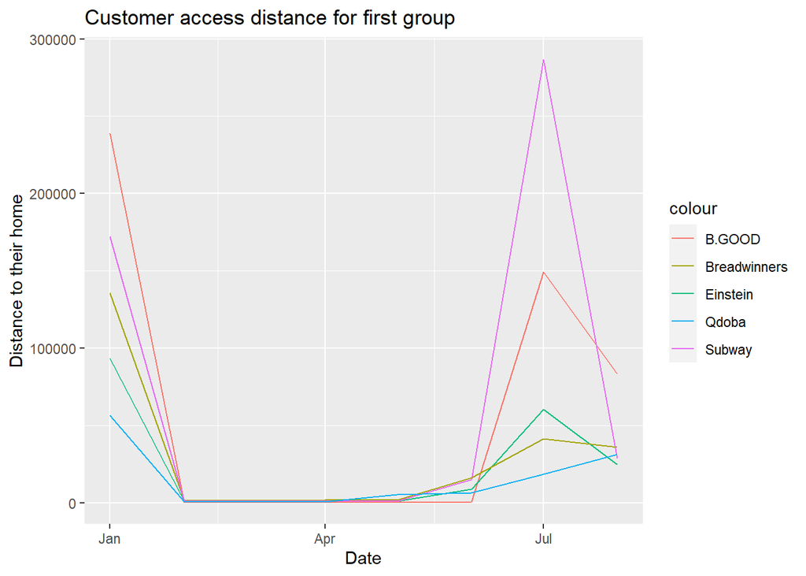

```r
library(ggplot2)

pgroup1 <- ggplot() + geom_line(data = B.GOOD, mapping = aes(x=date_range_start,y = distance_from_home,color = "B.GOOD")) + geom_line(data = Einstein, mapping = aes(x=date_range_start,y = distance_from_home,color = "Einstein")) + geom_line(data = Breadwinners, mapping = aes(x=date_range_start,y = distance_from_home,color = "Breadwinners")) + geom_line(data = Subway, mapping = aes(x=date_range_start,y = distance_from_home,color = "Subway")) + geom_line(data = Qdoba, mapping = aes(x=date_range_start,y = distance_from_home,color = "Qdoba")) + ggtitle("Customer access distance for first group") + xlab("Date") + ylab("Distance to their home") + theme_set(theme_bw())

pgroup1
```

## On this chart, Subway seems to have a high number in July. After checking the number, I found that the number is 286,790 meters, which means that the customers visiting in this month come from 286 kilometers away. I don’t think this is an outlier, but given that the number is calculated based on the distance between the customer’s phone and the store in the early morning hours of the day, I think it’s because the customer is traveling from home (or flying) to Boston and visiting Subway.

##This picture may inspire us in another aspect: look at the low and high tourist seasons in the Boston area, by looking at where the customers of these restaurants come from

```r
# select address: 779 Centre St
Soup <- subset(df_filter, location_name.x == "Soup Shack")
Soup <- Soup %>% filter(is.na(distance_from_home) != 1) %>% select(distance_from_home,date_range_end,date_range_start,location_name.x,street_address.x) %>% arrange(date_range_start) %>% filter(street_address.x == "779 Centre St")
Soup
```

```
## # A tibble: 8 × 5
##   distance_from_home date_range_end      date_range_start location_nam…¹ stree…²
##                <dbl> <dttm>              <date>           <chr>          <chr>
## 1               4076 2022-02-01 05:00:00 2022-01-01       Soup Shack     779 Ce…
## 2               7034 2022-03-01 05:00:00 2022-02-01       Soup Shack     779 Ce…
## 3               5592 2022-04-01 04:00:00 2022-03-01       Soup Shack     779 Ce…
## 4               4707 2022-05-01 04:00:00 2022-04-01       Soup Shack     779 Ce…
## 5               4445 2022-06-01 04:00:00 2022-05-01       Soup Shack     779 Ce…
## 6               3936 2022-07-01 04:00:00 2022-06-01       Soup Shack     779 Ce…
## 7               3526 2022-08-01 04:00:00 2022-07-01       Soup Shack     779 Ce…
## 8               4607 2022-09-01 04:00:00 2022-08-01       Soup Shack     779 Ce…
## # … with abbreviated variable names ¹location_name.x, ²street_address.x
```

```r
# select address: 86 Peterborough St
Sushi1 <- subset(df_filter, location_name.x == "Sushi Kappo")
Sushi1 <- Sushi %>% filter(is.na(distance_from_home) != 1) %>% select(distance_from_home,date_range_end,date_range_start,location_name.x,street_address.x) %>% arrange(date_range_start) %>% filter(street_address.x == "86 Peterborough St")
Sushi1
```

```
## # A tibble: 8 × 5
##   distance_from_home date_range_end      date_range_start location_nam…¹ stree…²
##                <dbl> <dttm>              <date>           <chr>          <chr>
## 1              11532 2022-02-01 05:00:00 2022-01-01       Sushi Kappo    86 Pet…
## 2               8723 2022-03-01 05:00:00 2022-02-01       Sushi Kappo    86 Pet…
## 3              25400 2022-04-01 04:00:00 2022-03-01       Sushi Kappo    86 Pet…
## 4              11532 2022-05-01 04:00:00 2022-04-01       Sushi Kappo    86 Pet…
## 5              16912 2022-06-01 04:00:00 2022-05-01       Sushi Kappo    86 Pet…
## 6              20149 2022-07-01 04:00:00 2022-06-01       Sushi Kappo    86 Pet…
## 7              45973 2022-08-01 04:00:00 2022-07-01       Sushi Kappo    86 Pet…
## 8              73577 2022-09-01 04:00:00 2022-08-01       Sushi Kappo    86 Pet…
## # … with abbreviated variable names ¹location_name.x, ²street_address.x
```

```r
# select address: 700 Atlantic Ave
Angelo <- subset(df_filter, location_name.x == "D'Angelo Grilled Sandwiches")
Angelo <- Angelo %>% filter(is.na(distance_from_home) != 1) %>% select(distance_from_home,date_range_end,date_range_start,location_name.x,street_address.x) %>% arrange(date_range_start) %>% filter(street_address.x == "700 Atlantic Ave.")
Angelo
```

```
## # A tibble: 8 × 5
##   distance_from_home date_range_end      date_range_start location_nam…¹ stree…²
##                <dbl> <dttm>              <date>           <chr>          <chr>
## 1              39310 2022-02-01 05:00:00 2022-01-01       D'Angelo Gril… 700 At…
## 2              30438 2022-03-01 05:00:00 2022-02-01       D'Angelo Gril… 700 At…
## 3              30495 2022-04-01 04:00:00 2022-03-01       D'Angelo Gril… 700 At…
## 4              28438 2022-05-01 04:00:00 2022-04-01       D'Angelo Gril… 700 At…
## 5              42101 2022-06-01 04:00:00 2022-05-01       D'Angelo Gril… 700 At…
## 6              69598 2022-07-01 04:00:00 2022-06-01       D'Angelo Gril… 700 At…
## 7              58975 2022-08-01 04:00:00 2022-07-01       D'Angelo Gril… 700 At…
## 8              48968 2022-09-01 04:00:00 2022-08-01       D'Angelo Gril… 700 At…
## # … with abbreviated variable names ¹location_name.x, ²street_address.x
```

```r
# select address: 313 Huntington Ave
#Poke <- subset(df_filter, location_name.x == "Poke Station and Kitchen")
#Poke <- Poke %>% filter(is.na(distance_from_home) != 1) %>% select(distance_from_home,date_range_end,date_range_start,location_name.x,street_address.x) %>% arrange(date_range_start) %>% filter(street_address.x == "313 Huntington Ave")
#Poke
#Give up because it has only 3 month record.




# select address: 100 Hanover St
Baking <- subset(df_filter, location_name.x == "Baking with Joy")
Baking <- Baking %>% filter(is.na(distance_from_home) != 1) %>% select(distance_from_home,date_range_end,date_range_start,location_name.x,street_address.x) %>% arrange(date_range_start) %>% filter(street_address.x == "100 Hanover St")
Baking
```

```
## # A tibble: 8 × 5
##   distance_from_home date_range_end      date_range_start location_nam…¹ stree…²
##                <dbl> <dttm>              <date>           <chr>          <chr>
## 1              13818 2022-02-01 05:00:00 2022-01-01       Baking with J… 100 Ha…
## 2               8821 2022-03-01 05:00:00 2022-02-01       Baking with J… 100 Ha…
## 3              21005 2022-04-01 04:00:00 2022-03-01       Baking with J… 100 Ha…
## 4              18544 2022-05-01 04:00:00 2022-04-01       Baking with J… 100 Ha…
## 5              21896 2022-06-01 04:00:00 2022-05-01       Baking with J… 100 Ha…
## 6              16881 2022-07-01 04:00:00 2022-06-01       Baking with J… 100 Ha…
## 7              22613 2022-08-01 04:00:00 2022-07-01       Baking with J… 100 Ha…
## 8              37696 2022-09-01 04:00:00 2022-08-01       Baking with J… 100 Ha…
## # … with abbreviated variable names ¹location_name.x, ²street_address.x
```

```r
# select address: 230 Congress St
Kwench <- subset(df_filter, location_name.x == "Kwench Juice Cafe")
Kwench <- Kwench %>% filter(is.na(distance_from_home) != 1) %>% select(distance_from_home,date_range_end,date_range_start,location_name.x,street_address.x) %>% arrange(date_range_start) %>% filter(street_address.x == "230 Congress St")
Kwench
```

```
## # A tibble: 8 × 5
##   distance_from_home date_range_end      date_range_start location_nam…¹ stree…²
##                <dbl> <dttm>              <date>           <chr>          <chr>
## 1              30980 2022-02-01 05:00:00 2022-01-01       Kwench Juice … 230 Co…
## 2              32713 2022-03-01 05:00:00 2022-02-01       Kwench Juice … 230 Co…
## 3              19804 2022-04-01 04:00:00 2022-03-01       Kwench Juice … 230 Co…
## 4              10604 2022-05-01 04:00:00 2022-04-01       Kwench Juice … 230 Co…
## 5              29639 2022-06-01 04:00:00 2022-05-01       Kwench Juice … 230 Co…
## 6              31176 2022-07-01 04:00:00 2022-06-01       Kwench Juice … 230 Co…
## 7              16229 2022-08-01 04:00:00 2022-07-01       Kwench Juice … 230 Co…
## 8              32713 2022-09-01 04:00:00 2022-08-01       Kwench Juice … 230 Co…
## # … with abbreviated variable names ¹location_name.x, ²street_address.x
```

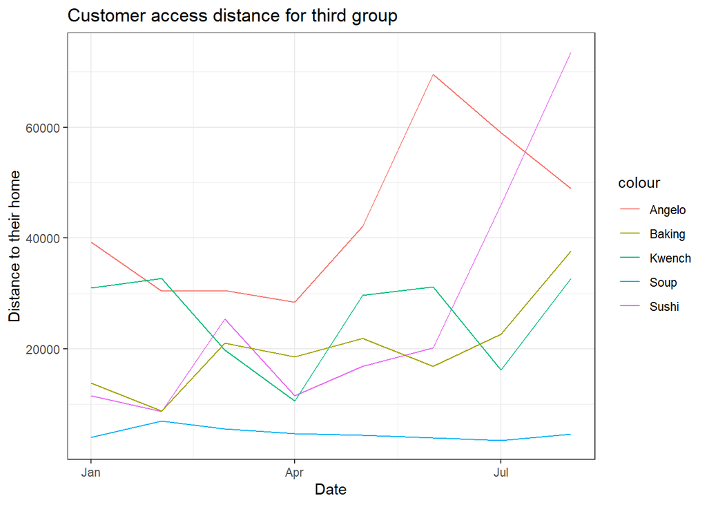

```r
pgroup3 <- ggplot() + geom_line(data = Soup, mapping = aes(x=date_range_start,y = distance_from_home,color = "Soup")) + geom_line(data = Sushi1, mapping = aes(x=date_range_start,y = distance_from_home,color = "Sushi")) + geom_line(data = Angelo, mapping = aes(x=date_range_start,y = distance_from_home,color = "Angelo")) + geom_line(data = Kwench, mapping = aes(x=date_range_start,y = distance_from_home,color = "Kwench")) + geom_line(data = Baking, mapping = aes(x=date_range_start,y = distance_from_home,color = "Baking")) + ggtitle("Customer access distance for third group") + xlab("Date") + ylab("Distance to their home") + theme_set(theme_bw())

pgroup3
```

```r
#Burger_d + La_d + Anna_d + Fins_d + Popeyes_d

Burger <- Burger %>% filter(is.na(distance_from_home) != 1) %>% select(distance_from_home,date_range_end,date_range_start,location_name.x,street_address.x) %>% arrange(date_range_start) %>% filter(street_address.x == "1 Maverick Sq")
# select address: 1 Maverick Sq
Burger
```

```
## # A tibble: 8 × 5
##   distance_from_home date_range_end      date_range_start location_nam…¹ stree…²
##                <dbl> <dttm>              <date>           <chr>          <chr>
## 1               3758 2022-02-01 05:00:00 2022-01-01       Burger King    1 Mave…
## 2               3842 2022-03-01 05:00:00 2022-02-01       Burger King    1 Mave…
## 3               3595 2022-04-01 04:00:00 2022-03-01       Burger King    1 Mave…
## 4               4981 2022-05-01 04:00:00 2022-04-01       Burger King    1 Mave…
## 5               3686 2022-06-01 04:00:00 2022-05-01       Burger King    1 Mave…
## 6               3873 2022-07-01 04:00:00 2022-06-01       Burger King    1 Mave…
## 7               4435 2022-08-01 04:00:00 2022-07-01       Burger King    1 Mave…
## 8               4099 2022-09-01 04:00:00 2022-08-01       Burger King    1 Mave…
## # … with abbreviated variable names ¹location_name.x, ²street_address.x
```

```r
La <- La %>% filter(is.na(distance_from_home) != 1) %>% select(distance_from_home,date_range_end,date_range_start,location_name.x,street_address.x) %>% arrange(date_range_start)


Anna <- Anna %>% filter(is.na(distance_from_home) != 1) %>% select(distance_from_home,date_range_end,date_range_start,location_name.x,street_address.x) %>% arrange(date_range_start)


Fins <- Fins %>% filter(is.na(distance_from_home) != 1) %>% select(distance_from_home,date_range_end,date_range_start,location_name.x,street_address.x) %>% arrange(date_range_start) %>% filter(street_address.x == "240 Cambridge St")
# select address: 240 Cambridge St


Popeyes <- Popeyes %>% filter(is.na(distance_from_home) != 1) %>% select(distance_from_home,date_range_end,date_range_start,location_name.x,street_address.x) %>% arrange(date_range_start)
```

```r
#Sushi_d+ Scali_d+ Jennifer_d_mean + Soup_d_mean+ Noon_d_mean
Sushi <- Sushi %>% filter(is.na(distance_from_home) != 1) %>% select(distance_from_home,date_range_end,date_range_start,location_name.x,street_address.x) %>% arrange(date_range_start)


Scali <- Scali %>% filter(is.na(distance_from_home) != 1) %>% select(distance_from_home,date_range_end,date_range_start,location_name.x,street_address.x) %>% arrange(date_range_start)


Jennifer <- Jennifer %>% filter(is.na(distance_from_home) != 1) %>% select(distance_from_home,date_range_end,date_range_start,location_name.x,street_address.x) %>% arrange(date_range_start)


Soup <- Soup %>% filter(is.na(distance_from_home) != 1) %>% select(distance_from_home,date_range_end,date_range_start,location_name.x,street_address.x) %>% arrange(date_range_start)
Soup
```

```
## # A tibble: 8 × 5
##   distance_from_home date_range_end      date_range_start location_nam…¹ stree…²
##                <dbl> <dttm>              <date>           <chr>          <chr>
## 1               4076 2022-02-01 05:00:00 2022-01-01       Soup Shack     779 Ce…
## 2               7034 2022-03-01 05:00:00 2022-02-01       Soup Shack     779 Ce…
## 3               5592 2022-04-01 04:00:00 2022-03-01       Soup Shack     779 Ce…
## 4               4707 2022-05-01 04:00:00 2022-04-01       Soup Shack     779 Ce…
## 5               4445 2022-06-01 04:00:00 2022-05-01       Soup Shack     779 Ce…
## 6               3936 2022-07-01 04:00:00 2022-06-01       Soup Shack     779 Ce…
## 7               3526 2022-08-01 04:00:00 2022-07-01       Soup Shack     779 Ce…
## 8               4607 2022-09-01 04:00:00 2022-08-01       Soup Shack     779 Ce…
## # … with abbreviated variable names ¹location_name.x, ²street_address.x
```

```r
Noon <- Noon %>% filter(is.na(distance_from_home) != 1) %>% select(distance_from_home,date_range_end,date_range_start,location_name.x,street_address.x) %>% arrange(date_range_start)
Noon
```

```
## # A tibble: 4 × 5
##   distance_from_home date_range_end      date_range_start location_nam…¹ stree…²
##                <dbl> <dttm>              <date>           <chr>          <chr>
## 1              24175 2022-06-01 04:00:00 2022-05-01       Noon Mediterr… 95 Sum…
## 2              35047 2022-07-01 04:00:00 2022-06-01       Noon Mediterr… 95 Sum…
## 3              31987 2022-08-01 04:00:00 2022-07-01       Noon Mediterr… 95 Sum…
## 4              24246 2022-09-01 04:00:00 2022-08-01       Noon Mediterr… 95 Sum…
## # … with abbreviated variable names ¹location_name.x, ²street_address.x
```

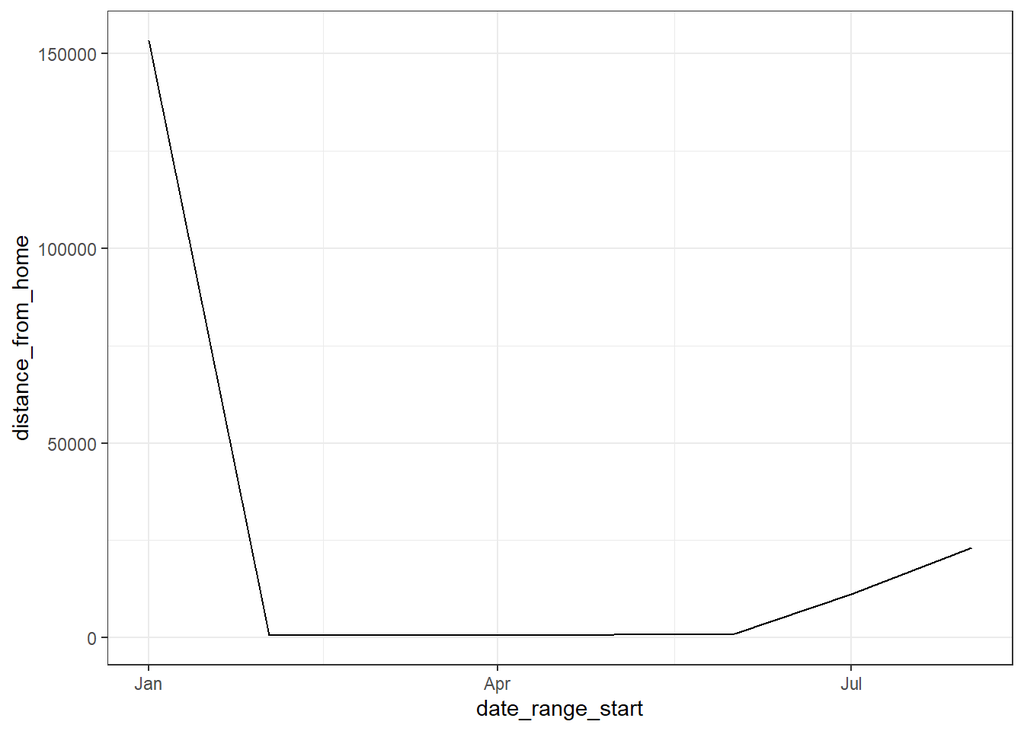

```r
library(ggplot2)
pTatte <- ggplot(data = Tatte, mapping = aes(x = date_range_start, y = distance_from_home))
pTatte + geom_line()
```

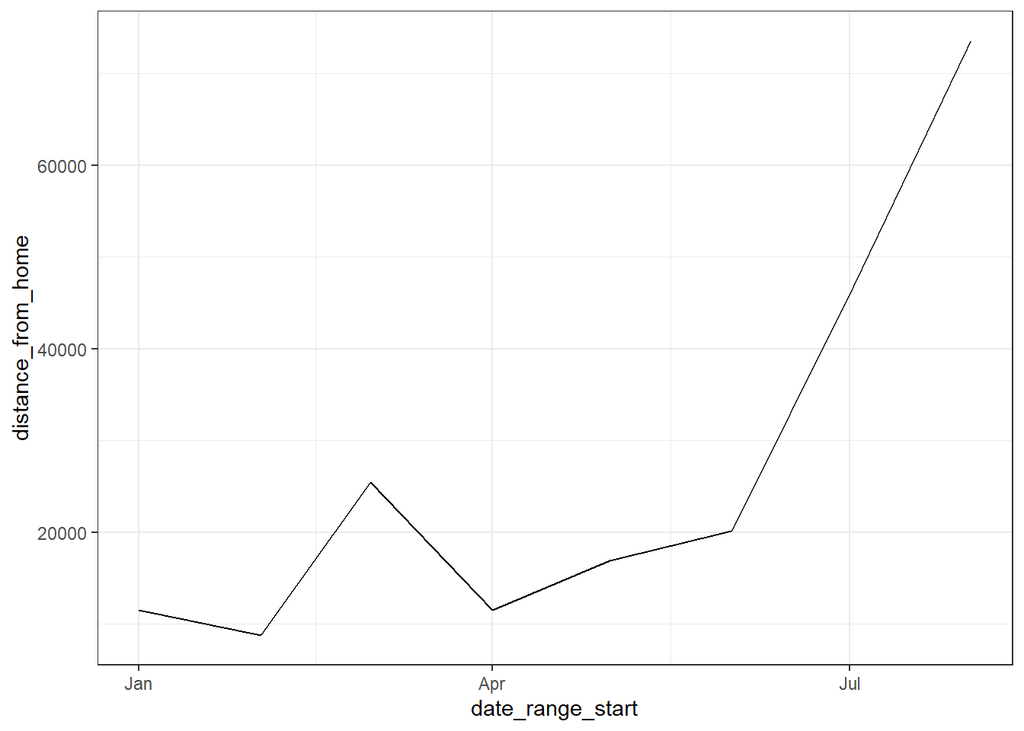

```r
pSushi <- ggplot(data = Sushi, mapping = aes(x = date_range_start, y = distance_from_home))
pSushi + geom_line()
```

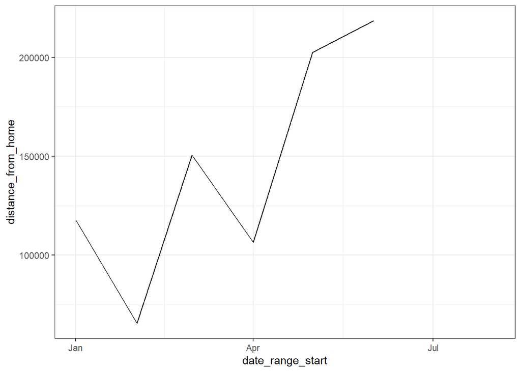

```r
pMOOYAH <- ggplot(data = MOOYAH, mapping = aes(x = date_range_start, y = distance_from_home))
pMOOYAH + geom_line()
```

```r
startday <- as.Date("2022-05-01")
endday<- as.Date("2022-06-02")

Soup <- Soup[which(Soup$date_range_start >= startday & Soup$date_range_end <= endday),]
Soup
```

```
## # A tibble: 1 × 5
##   distance_from_home date_range_end      date_range_start location_nam…¹ stree…²
##                <dbl> <dttm>              <date>           <chr>          <chr>
## 1               4445 2022-06-01 04:00:00 2022-05-01       Soup Shack     779 Ce…
## # … with abbreviated variable names ¹location_name.x, ²street_address.x
```

```r
Tatte <- Tatte[which(Tatte$date_range_start >= startday & Tatte$date_range_end <= endday),]
Tatte
```

```
## # A tibble: 0 × 5
## # … with 5 variables: distance_from_home <dbl>, raw_visit_counts <dbl>,
## #   date_range_start <date>, location_name.x <chr>, street_address.x <chr>
```